# DR analysis

### Preprocess – missing values

- 1. ) several patients may have wrong weight values, since they are no-RRT patients, remove them entirly
- 2. ) cvp have many missing values( > 863/1271), so do urine_acid, bnp and base excess(this one exclude admission), better remove them before analysis.
- 3. ) And the third timestamp(get better date) have about a half missing data, for more then 500 no-rrt patients can’t find a urine increase time according to the definition. This may cause bias, but analysis below will still include these variables.

### 1. Baseline characteristics, stratified by rrt

```
##                                       "Stratified by rrt"
##  ""                                    "0"              "1"
##   "n"                                  "  1124"         "    93"
##   "age (mean (sd))"                    " 70.80 (13.81)" " 67.78 (13.68)"
##   "gender = 1 (%)"                     "   707 (62.9) " "    62 (66.7) "
##   "height (mean (sd))"                 "169.60 (10.58)" "169.61 (10.60)"
##   "weight_adm (mean (sd))"             " 84.05 (24.00)" " 85.58 (28.86)"
##   "bmi (mean (sd))"                    " 29.11 (7.56)"  " 29.55 (9.39)"
##   "bbr = 1 (%)"                        "  1018 (90.6) " "    75 (80.6) "
##   "inotropes_vasopressor = 1 (%)"      "   850 (75.6) " "    73 (78.5) "
##   "acei = 1 (%)"                       "   497 (44.2) " "    13 (14.0) "
##   "mra = 1 (%)"                        "   218 (19.4) " "     5 ( 5.4) "
##   "vasodilator = 1 (%)"                "   525 (46.7) " "    41 (44.1) "
##   "ischemic_heart_disease = 1 (%)"     "   758 (67.4) " "    52 (55.9) "
##   "cardiomyopathies = 1 (%)"           "   274 (24.4) " "    13 (14.0) "
##   "valvular_disease = 1 (%)"           "   182 (16.2) " "    12 (12.9) "
##   "atrial_fibrilation = 1 (%)"         "   585 (52.0) " "    40 (43.0) "
##   "hyperlipidemia = 1 (%)"             "   392 (34.9) " "    13 (14.0) "
##   "hypertension = 1 (%)"               "   268 (23.8) " "    33 (35.5) "
##   "diabetes = 1 (%)"                   "   471 (41.9) " "    33 (35.5) "
##   "sleep_disordered_breathing = 1 (%)" "    87 ( 7.7) " "     2 ( 2.2) "
##   "renal_failure = 1 (%)"              "   332 (29.5) " "    43 (46.2) "
##   "anemia = 1 (%)"                     "   402 (35.8) " "    30 (32.3) "
##   "infection = 1 (%)"                  "   652 (58.0) " "    72 (77.4) "
##   "alcohol_abuse = 1 (%)"              "    53 ( 4.7) " "     3 ( 3.2) "
##   "hr_adm (mean (sd))"                 " 91.35 (19.53)" " 90.88 (20.51)"
##   "sbp_adm (mean (sd))"                "114.63 (22.25)" "113.59 (25.10)"
##   "dbp_adm (mean (sd))"                " 62.56 (17.05)" " 59.43 (14.46)"
##   "spo2_adm (mean (sd))"               " 89.99 (7.11)"  " 94.86 (9.98)"
##   "tem_adm (mean (sd))"                " 36.33 (2.30)"  " 35.99 (3.91)"
##   "gfr_adm (mean (sd))"                " 51.33 (26.97)" " 32.99 (25.20)"
##   "base_excess_adm (mean (sd))"        " -0.38 (5.62)"  " -1.78 (5.56)"
##   "hco3_adm (mean (sd))"               " 24.54 (5.09)"  " 22.52 (5.67)"
##   "ph_adm (mean (sd))"                 "  7.38 (0.10)"  "  7.36 (0.10)"
##   "hemoglobin_adm (mean (sd))"         " 11.24 (2.01)"  " 10.38 (1.81)"
##   "albumin_adm (mean (sd))"            "  3.20 (0.60)"  "  2.98 (0.62)"
##   "potassium_adm (mean (sd))"          "  4.31 (0.76)"  "  4.63 (1.03)"
##   "sodium_adm (mean (sd))"             "137.59 (5.13)"  "137.37 (4.27)"
##   "creatinine_adm (mean (sd))"         "  1.61 (0.95)"  "  2.72 (1.71)"
##   "bun_adm (mean (sd))"                " 38.40 (24.74)" " 58.08 (32.67)"
```

[output cut: 25 more lines]

```
##   "hr_adm (mean (sd))"                 " 0.826" ""
##   "sbp_adm (mean (sd))"                " 0.667" ""
##   "dbp_adm (mean (sd))"                " 0.086" ""
##   "spo2_adm (mean (sd))"               "<0.001" ""
##   "tem_adm (mean (sd))"                " 0.196" ""
##   "gfr_adm (mean (sd))"                "<0.001" ""
##   "base_excess_adm (mean (sd))"        " 0.026" ""
##   "hco3_adm (mean (sd))"               "<0.001" ""
##   "ph_adm (mean (sd))"                 " 0.258" ""
##   "hemoglobin_adm (mean (sd))"         "<0.001" ""
##   "albumin_adm (mean (sd))"            " 0.001" ""
##   "potassium_adm (mean (sd))"          "<0.001" ""
##   "sodium_adm (mean (sd))"             " 0.679" ""
##   "creatinine_adm (mean (sd))"         "<0.001" ""
##   "bun_adm (mean (sd))"                "<0.001" ""
```

### 2. Characteristics of fluid value and outcomes

```r
catvars <- c("los_hos", "los_icu", "hospital_expire_flag", "add_drug_therapy", "change_drug_therapy", "fluid_overload_to_rrt", "daily_fluid_overload_to_rrt", "urine_output_to_rrt", "daily_uo_to_rrt", "total_input_to_discharge", "total_output_to_discharge", "fluid_overload_to_dis", "urine_output_to_dis")
test.table <- CreateTableOne(vars=catvars, strata = "rrt", data = data.std)
a <- print(test.table, quote = TRUE)[, -4]
```

```
##                                            "Stratified by rrt"
##  ""                                         "0"
##   "n"                                       "    1124"
##   "los_hos (mean (sd))"                     "  365.03 (293.35)"
##   "los_icu (mean (sd))"                     "  207.88 (216.71)"
##   "hospital_expire_flag = 1 (%)"            "     210 (18.7) "
##   "add_drug_therapy = 1 (%)"                "     524 (46.6) "
##   "change_drug_therapy = 1 (%)"             "     161 (14.3) "
##   "fluid_overload_to_rrt (mean (sd))"       " 3817.32 (11761.61)"
##   "daily_fluid_overload_to_rrt (mean (sd))" "  842.78 (2721.75)"
##   "urine_output_to_rrt (mean (sd))"         " 5051.15 (7145.66)"
##   "daily_uo_to_rrt (mean (sd))"             " 1636.74 (1298.75)"
##   "total_input_to_discharge (mean (sd))"    "27478.78 (39426.81)"
##   "total_output_to_discharge (mean (sd))"   "19813.67 (22669.53)"
##   "fluid_overload_to_dis (mean (sd))"       " 7791.45 (29412.27)"
##   "urine_output_to_dis (mean (sd))"         "17864.05 (20817.85)"
##                                            "Stratified by rrt"
##  ""                                         "1"                   "p"
##   "n"                                       "      93"            ""
##   "los_hos (mean (sd))"                     "  675.44 (527.69)"   "<0.001"
##   "los_icu (mean (sd))"                     "  465.47 (421.29)"   "<0.001"
##   "hospital_expire_flag = 1 (%)"            "      37 (39.8) "    "<0.001"
##   "add_drug_therapy = 1 (%)"                "      37 (39.8) "    " 0.245"
##   "change_drug_therapy = 1 (%)"             "       8 ( 8.6) "    " 0.168"
##   "fluid_overload_to_rrt (mean (sd))"       " 9117.04 (12311.12)" "<0.001"
##   "daily_fluid_overload_to_rrt (mean (sd))" " 1976.48 (4131.94)"  "<0.001"
##   "urine_output_to_rrt (mean (sd))"         "10612.53 (18342.06)" "<0.001"
##   "daily_uo_to_rrt (mean (sd))"             "  974.25 (884.61)"   "<0.001"
##   "total_input_to_discharge (mean (sd))"    "49305.14 (42549.91)" "<0.001"
##   "total_output_to_discharge (mean (sd))"   "38585.34 (35196.25)" "<0.001"
##   "fluid_overload_to_dis (mean (sd))"       "10719.80 (20891.41)" " 0.354"
##   "urine_output_to_dis (mean (sd))"         "17497.71 (23006.66)" " 0.874"
##                                            "Stratified by rrt"
##  ""                                         "test"
##   "n"                                       ""
##   "los_hos (mean (sd))"                     ""
##   "los_icu (mean (sd))"                     ""
##   "hospital_expire_flag = 1 (%)"            ""
##   "add_drug_therapy = 1 (%)"                ""
##   "change_drug_therapy = 1 (%)"             ""
##   "fluid_overload_to_rrt (mean (sd))"       ""
##   "daily_fluid_overload_to_rrt (mean (sd))" ""
##   "urine_output_to_rrt (mean (sd))"         ""
##   "daily_uo_to_rrt (mean (sd))"             ""
##   "total_input_to_discharge (mean (sd))"    ""
##   "total_output_to_discharge (mean (sd))"   ""
##   "fluid_overload_to_dis (mean (sd))"       ""
##   "urine_output_to_dis (mean (sd))"         ""
```

```r
g1 <- paste('Non RRT (n=', a[1,1], ')')
g2 <- paste('RRT (n=', a[1,2], ')')
colnames(a) <- c(g1, g2, 'p-value')
a <- a[-1, ]
# write.csv(a, '~/Documents/python-projects/Datathon-DR/report/outcomevariable_summary.csv')
```

### 2. Visiualize data

#### a.) There are 1217 patients in our dataset, among which 561 add drug dose after diuretic resist, 169 change drug, and 93 of them finally had dialysis.

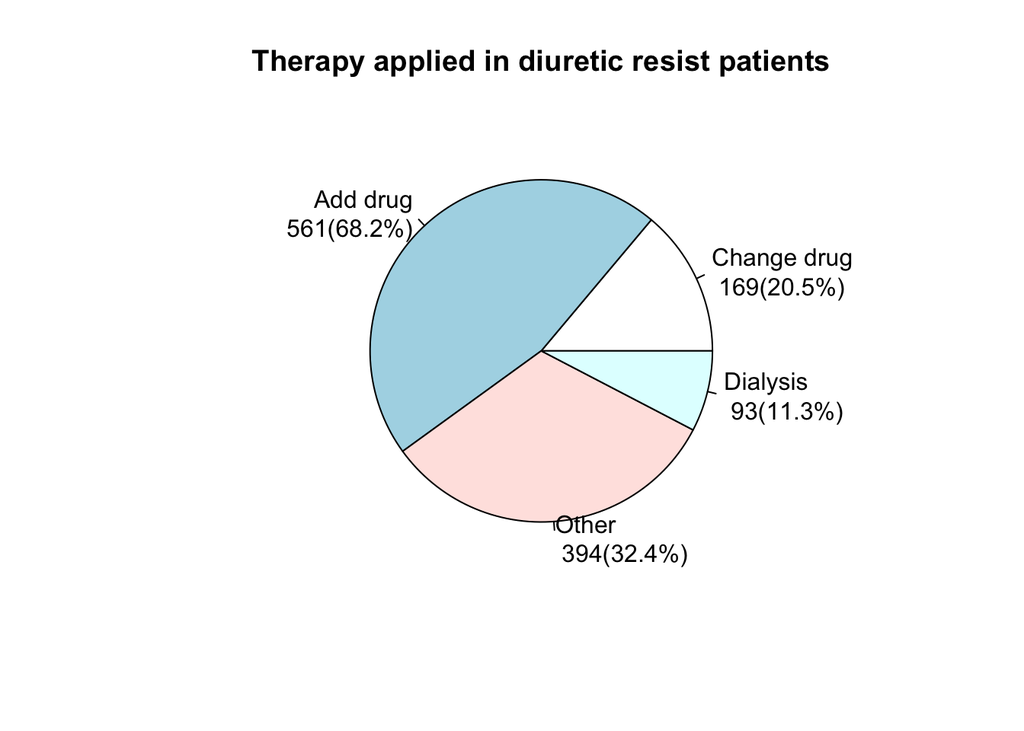

####b. ) 247 of them died in hospital. 970 survived

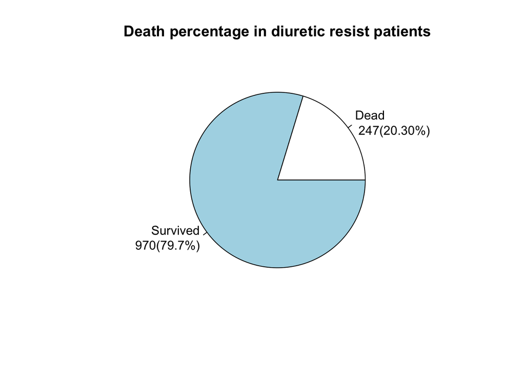

### 3. Missing data interpolation

- 1. Case delete for patients with many missing values
- 2. Linear interpolation for lab test values(e.g heart rate after rrt was interpolate use hr on admmission, hr after DR and hr on discharge)

[output not shown]

[output not shown]

[output not shown]

[output not shown]

[output not shown]

### In our dataset, rrt : no-rrt is almost 1:10, it’s very unbalanced.

#### Several methods can be applied to handle a unbalanced dataset, including oversampling, downsampling, synthetic method etc.

### Use random forest to see if the two cluster can be seperate

#### While the first pic applied oversampling method, the second is sampled data use synthetic data sampling method

#### The first may have overfitting issuse!

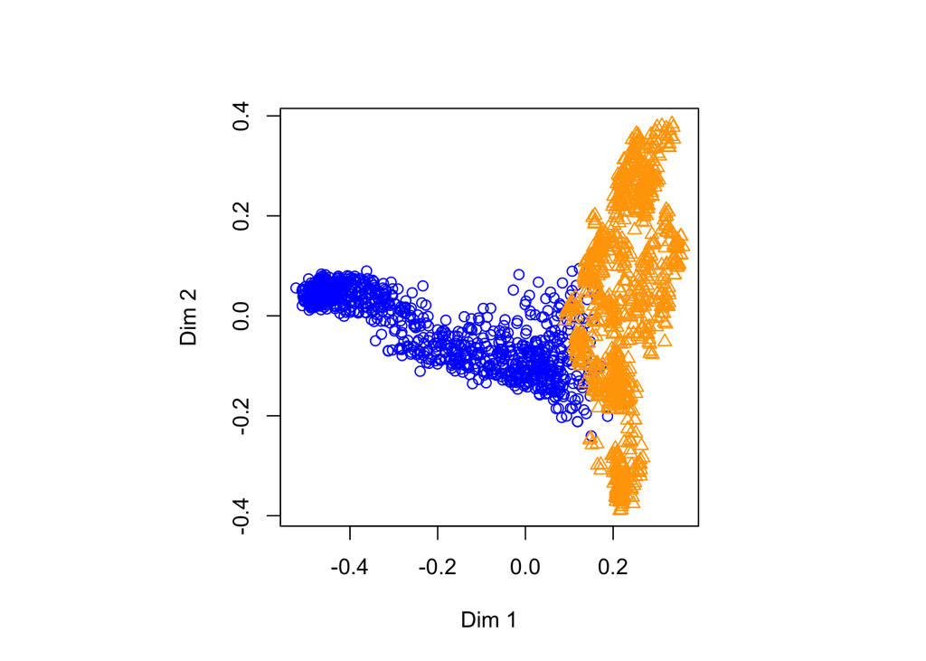

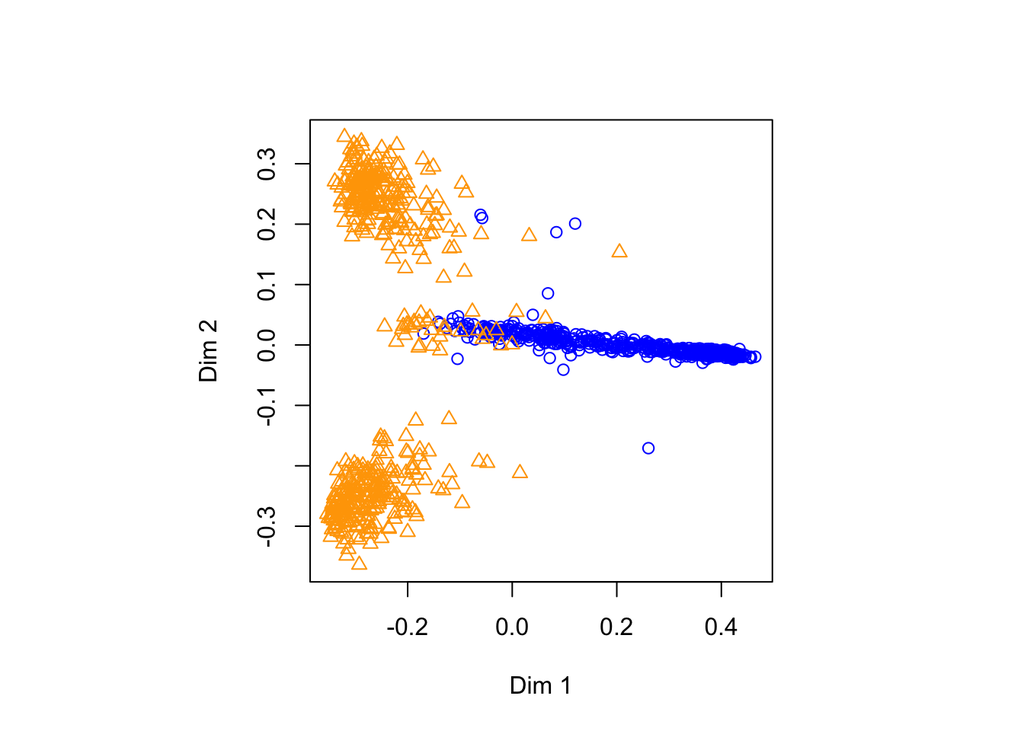

### Use PCA to deduct dimension

#### It’s not clear that rrt and no-rrt can be seperate.

#### Here’s rouse a question, is PCA proper to show the distinguish of clusters?

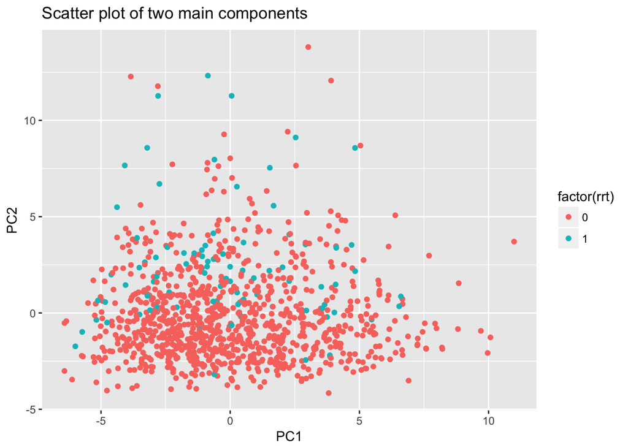

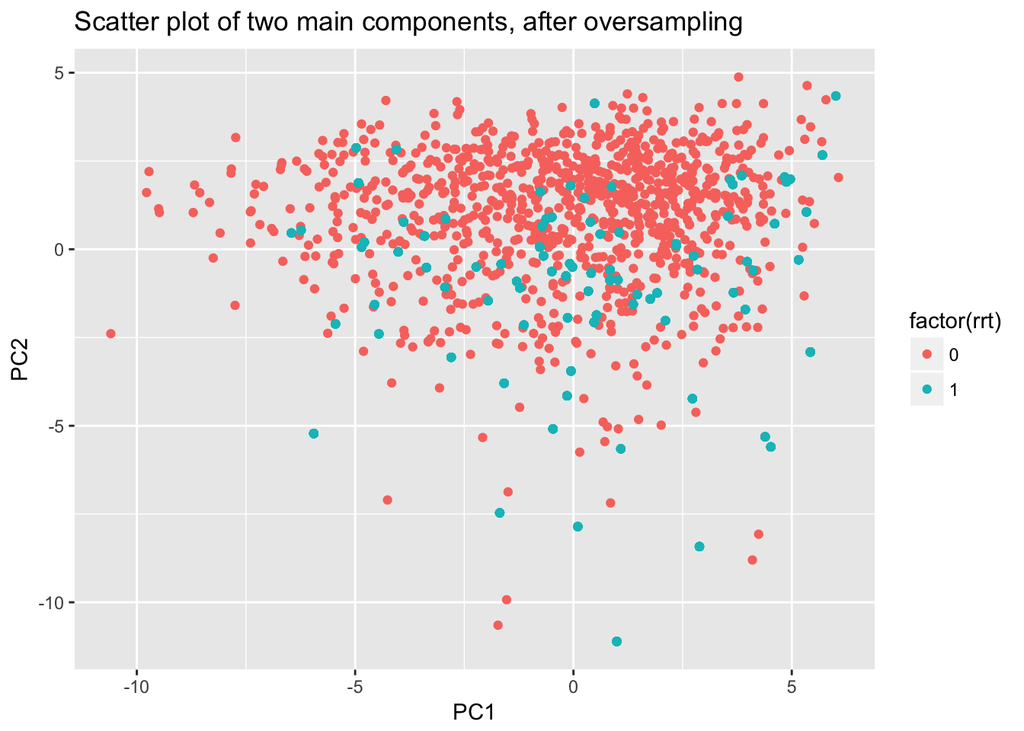

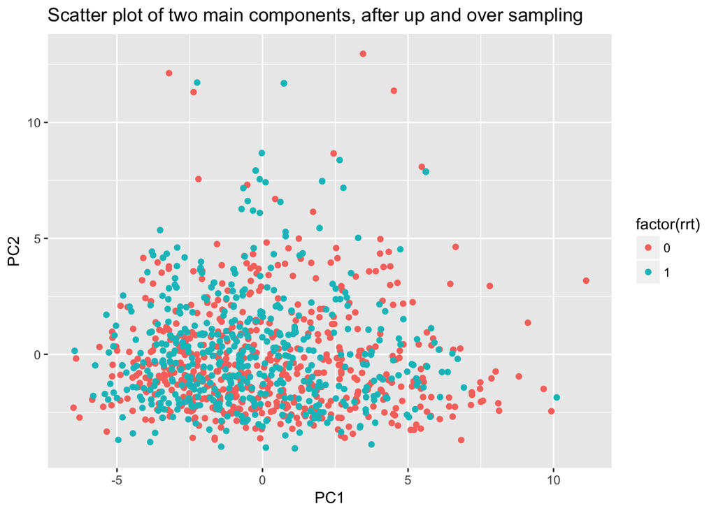

```
##                                                 OR (95%CI) p value
## (Intercept)                   0.01657 ( 0.00281 , 0.0936 )       0
## gender1                      2.23662 ( 1.45216 , 3.48031 )   3e-04
## los_hos                      1.00062 ( 1.00022 , 1.00103 ) 0.00279
## los_icu                       1.00086 ( 1.00033 , 1.0014 ) 0.00157
## add_drug_therapy1             0.58826 ( 0.39124 , 0.8795 ) 0.01012
## weight_adm                   1.00548 ( 0.99996 , 1.01111 ) 0.05276
## acei1                         0.08383 ( 0.04811 , 0.1417 )       0
## mra1                         0.56741 ( 0.27312 , 1.14805 ) 0.12123
## atrial_fibrilation1          0.45326 ( 0.30128 , 0.67625 ) 0.00012
## hyperlipidemia1              0.33739 ( 0.20776 , 0.54037 )   1e-05
## renal_failure1               3.41411 ( 2.23506 , 5.28628 )       0
## nosocomial_hypoproteinemia1  2.73079 ( 1.74307 , 4.29836 )   1e-05
## nosocomial_anemia1          6.82653 ( 4.34236 , 10.89207 )       0
## nosocomial_hyponatremia1     4.41903 ( 2.82068 , 6.99651 )       0
## urine_output_to_rrt                1.00001 ( 1 , 1.00002 ) 0.13234
## daily_uo_to_rrt               0.99956 ( 0.9994 , 0.99971 )       0
## total_output_to_discharge          1.00001 ( 1 , 1.00001 ) 0.01295
## fluid_overload_to_dis        0.99999 ( 0.99998 , 0.99999 )   2e-05
## urine_output_to_dis          0.99998 ( 0.99997 , 0.99999 )       0
## hr_therapy                   0.98758 ( 0.97887 , 0.99615 ) 0.00505
## sbp_therapy                  1.01727 ( 1.00968 , 1.02517 )   1e-05
## bun_dr                       1.00449 ( 0.99884 , 1.01017 ) 0.11888
## potassium_therapy            1.21467 ( 0.94397 , 1.56585 ) 0.13148
```